# Data Visualization Part I: Exploratory Graphics

First, you could change the size of the points:

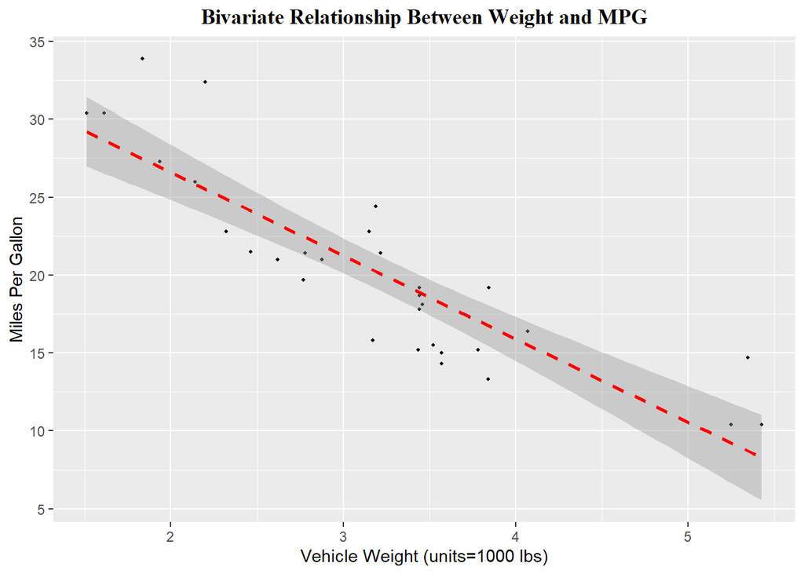

```r
scatter_plot <- ggplot(mtcars, aes(x=wt, y=mpg)) +
  geom_point(size=0.75) +
  ggtitle("Bivariate Relationship Between Weight and MPG") +
  theme(plot.title=element_text(hjust=0.5,
                                face="bold", family="serif")) +
  xlab("Vehicle Weight (units=1000 lbs)") +
  ylab("Miles Per Gallon") +
  scale_y_continuous(breaks = seq(5, 35, by=5),
                     minor_breaks = seq(5, 35, by=2.5)) +
  geom_smooth(method="lm", color="red", linetype="dashed")

scatter_plot
```

A bit less overlap! For context, the default size is 1.5 and you can set positive values from 0 to the largest positive value you can fit into R. Anything above 4 or 5 gets a little ridiculous, though.

For the second option, we can add a jitter to each point so that it moves its location very slightly in a random direction. This is especially helpful when you have **many** observations (e.g., in the thousands and ten-thousands).

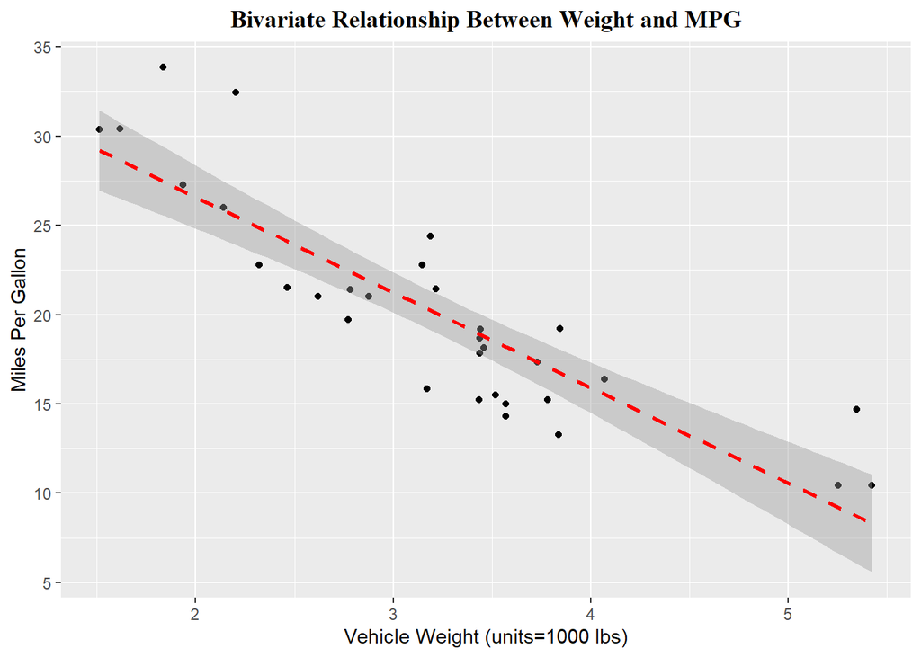

```r
scatter_plot <- ggplot(mtcars, aes(x=wt, y=mpg)) +
  geom_point(position="jitter") +
  ggtitle("Bivariate Relationship Between Weight and MPG") +
  theme(plot.title=element_text(hjust=0.5,
                                face="bold", family="serif")) +
  xlab("Vehicle Weight (units=1000 lbs)") +
  ylab("Miles Per Gallon") +
  scale_y_continuous(breaks = seq(5, 35, by=5),
                     minor_breaks = seq(5, 35, by=2.5)) +
  geom_smooth(method="lm", color="red", linetype="dashed")

scatter_plot
```

As you can see, it’s a very slight change. You can use this in conjunction with size to make overlapping points easier to see.

Third, you can change the transparency of the points using alpha= option, like so:

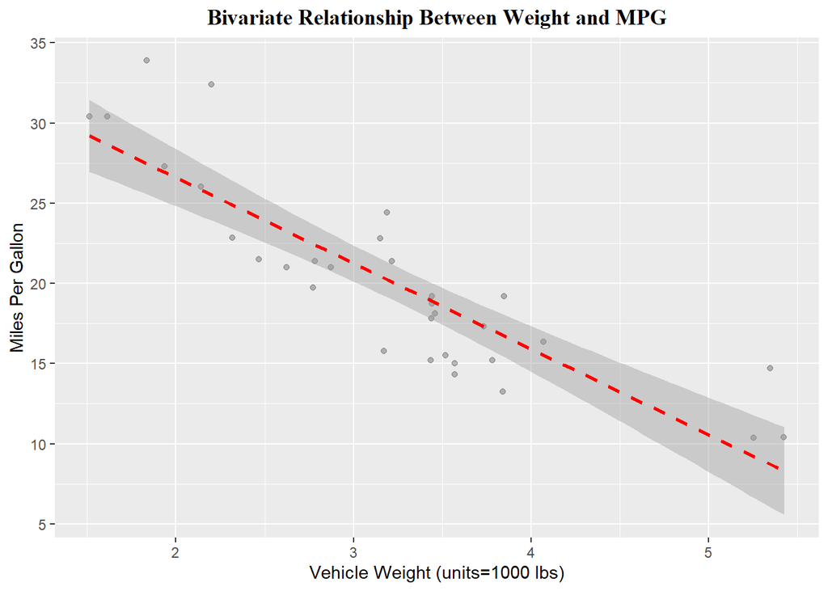

```r
scatter_plot <- ggplot(mtcars, aes(x=wt, y=mpg)) +
  geom_point(alpha=0.25, position="jitter") +
  ggtitle("Bivariate Relationship Between Weight and MPG") +
  theme(plot.title=element_text(hjust=0.5,
                                face="bold", family="serif")) +
  xlab("Vehicle Weight (units=1000 lbs)") +
  ylab("Miles Per Gallon") +
  scale_y_continuous(breaks = seq(5, 35, by=5),
                     minor_breaks = seq(5, 35, by=2.5)) +
  geom_smooth(method="lm", color="red", linetype="dashed")

scatter_plot
```

Values for alpha range from 0 to 1, with 0 making the points invisible and 1 making them appear as they do normally.

#### More Fun with Scatterplots

There are a few other neat things you can do with a scatterplot, including:

- Adding additional lines to represent the means of the x-axis and y-axis variables
- Incorporating a third variable by changing the **color** of the points by values on another variable
- Incorporating another variable that corresponds to the **size** of the points.
- Changing the shape of the points (and you can make this vary by another variable, too)

Let’s see these options in action.

First, adding lines for the averages:

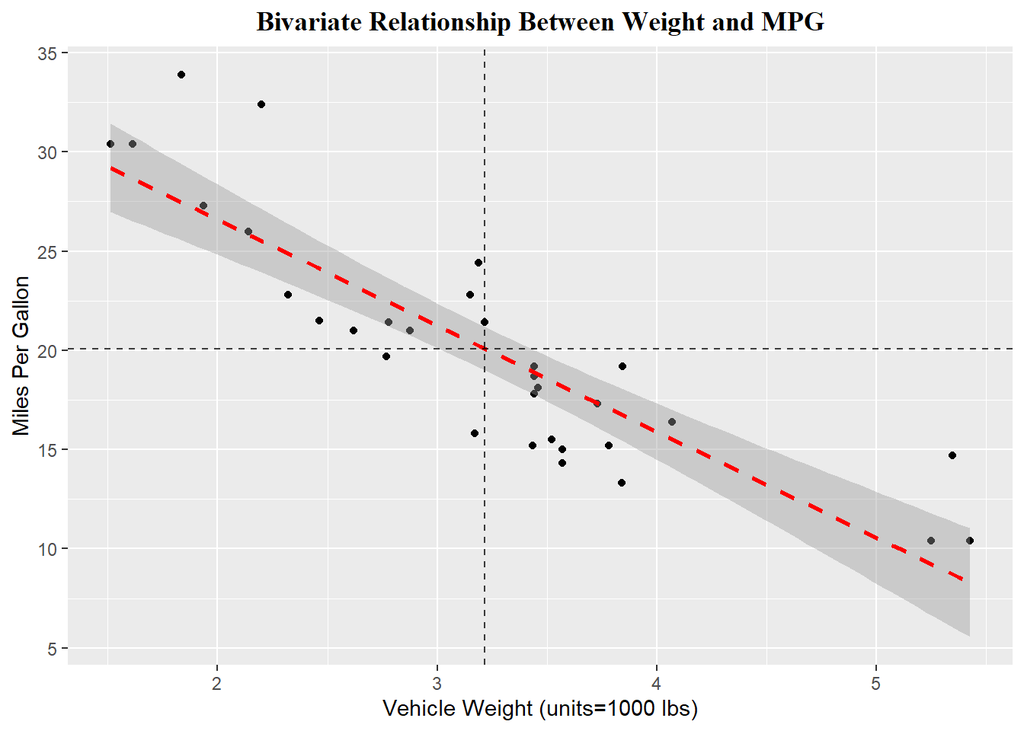

```r
scatter_plot <- ggplot(mtcars, aes(x=wt, y=mpg)) +
  geom_point() +
  ggtitle("Bivariate Relationship Between Weight and MPG") +
  theme(plot.title=element_text(hjust=0.5,
                                face="bold", family="serif")) +
  xlab("Vehicle Weight (units=1000 lbs)") +
  ylab("Miles Per Gallon") +
  scale_y_continuous(breaks = seq(5, 35, by=5),
                     minor_breaks = seq(5, 35, by=2.5)) +
  geom_smooth(method="lm", color="red", linetype="dashed") +
  geom_hline(aes(yintercept=mean(mtcars$mpg)),
             linetype="dashed", alpha=0.75) +
  geom_vline(aes(xintercept=mean(mtcars$wt)),
             linetype="dashed", alpha=0.75)

scatter_plot
```

Now, I want to adjust the color of the points to correspond to another variable. I think the number of cylinders probably also affects miles per gallon, above and beyond the weight of the vehicle.

Let’s see what that looks like:

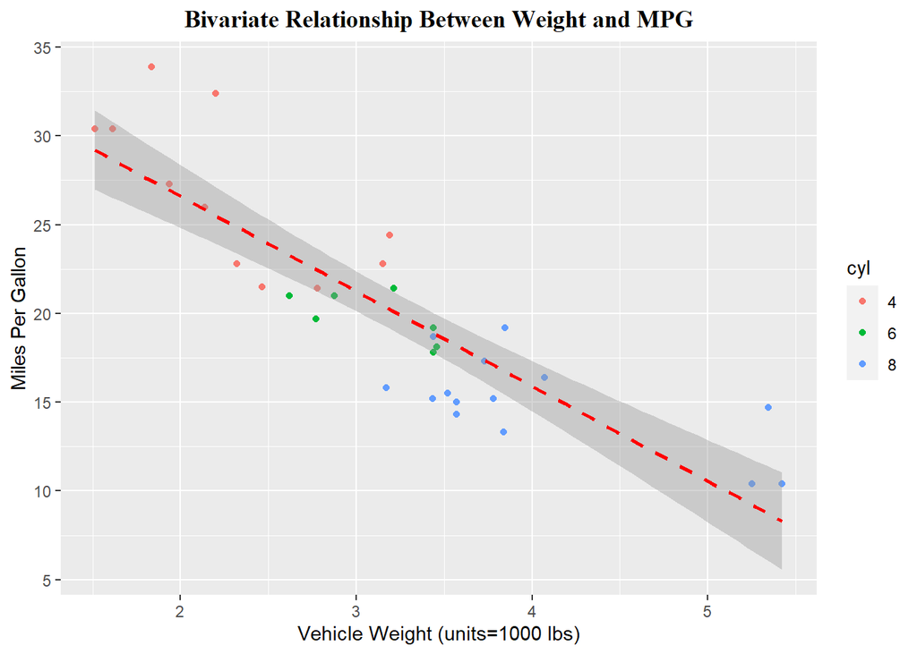

```r
scatter_plot <- ggplot(mtcars, aes(x=wt, y=mpg, color=cyl)) +
  geom_point() +
  ggtitle("Bivariate Relationship Between Weight and MPG") +
  theme(plot.title=element_text(hjust=0.5,
                                face="bold", family="serif")) +
  xlab("Vehicle Weight (units=1000 lbs)") +
  ylab("Miles Per Gallon") +
  scale_y_continuous(breaks = seq(5, 35, by=5),
                     minor_breaks = seq(5, 35, by=2.5)) +
  geom_smooth(method="lm", color="red", linetype="dashed")

scatter_plot
```

Somewhat interesting - looks like the relationship is somewhat flat for 6 and 8-cylinder engines and clearly negative for 4-cylinder engines.

Now, let’s account for another variable using the **size** of the points. I think the displacement of the pistons in the engine can also affect miles per gallon, net of the effect of weight. Let’s see how that looks:

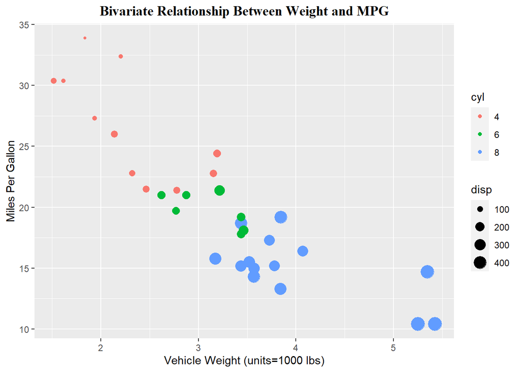

```r
scatter_plot <- ggplot(mtcars, aes(x=wt, y=mpg, color=cyl, size=disp)) +
  geom_point() +
  ggtitle("Bivariate Relationship Between Weight and MPG") +
  theme(plot.title=element_text(hjust=0.5,
                                face="bold", family="serif")) +
  xlab("Vehicle Weight (units=1000 lbs)") +
  ylab("Miles Per Gallon") +
  scale_y_continuous(breaks = seq(5, 35, by=5),
                     minor_breaks = seq(5, 35, by=2.5))
scatter_plot
```

Side note - I took out the regression line because the multiple repeated options began to interfere with another.

Higher values of piston displacement = more power generated by the engine and, as a consequence, using more fuel. Looks like more displacement = lower mpg, all else equal.

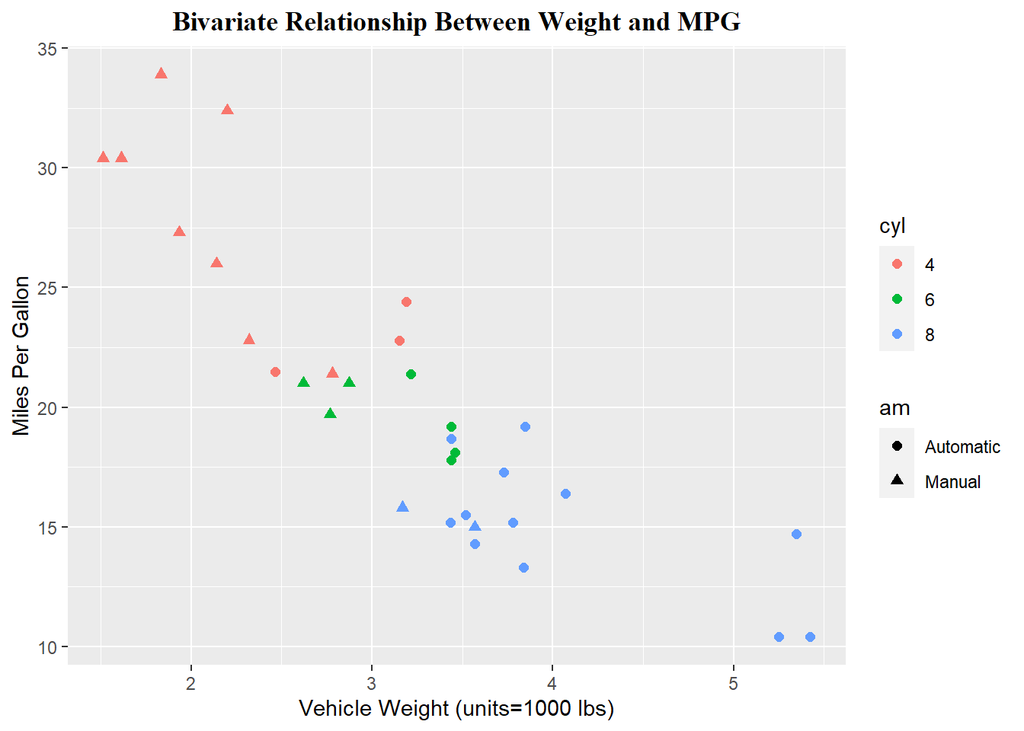

```r
scatter_plot <- ggplot(mtcars, aes(x=wt, y=mpg, color=cyl, shape=am)) +
  geom_point(size=2) +
  ggtitle("Bivariate Relationship Between Weight and MPG") +
  theme(plot.title=element_text(hjust=0.5,
                                face="bold", family="serif")) +
  xlab("Vehicle Weight (units=1000 lbs)") +
  ylab("Miles Per Gallon") +
  scale_y_continuous(breaks = seq(5, 35, by=5),
                     minor_breaks = seq(5, 35, by=2.5))

scatter_plot
```

Interesting, but still looks like a negative relationship within transmission type. Not too much going on there.

**One final note** - you can add text labels to the points! Let’s see that in action:

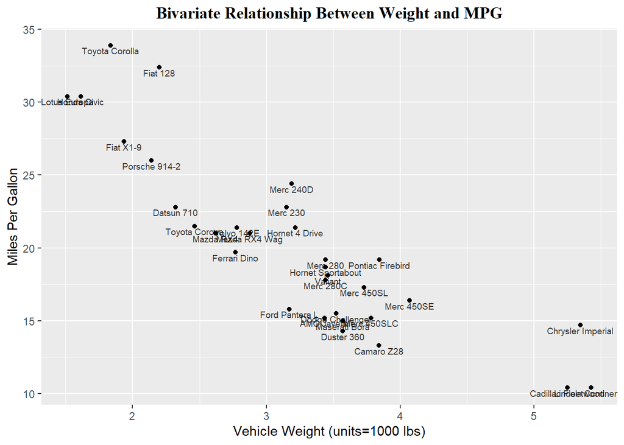

```r
scatter_plot <- ggplot(mtcars, aes(x=wt, y=mpg)) +
  geom_point() +
  ggtitle("Bivariate Relationship Between Weight and MPG") +
  theme(plot.title=element_text(hjust=0.5,
                                face="bold", family="serif")) +
  xlab("Vehicle Weight (units=1000 lbs)") +
  ylab("Miles Per Gallon") +
  scale_y_continuous(breaks = seq(5, 35, by=5),
                     minor_breaks = seq(5, 35, by=2.5)) +
  geom_text(aes(label=rownames(mtcars)),
            size=2.5, vjust=1.25, alpha=.8)
scatter_plot
```

You can use the size, vjust, and alpha options to adjust how the labels appear, but even so they will probably end up overlapping a bit. It would be easier to avoid overlap if you subset the data first by some variable, then make plots with text labels using the smaller subsamples.